# Advertising Response Measurement

Team K

4/25/2019

## Introduction

- The goal of any marketing campaign is to increase sales, either in short-term or long-term, and each campaign or marketing channel should be evaluated based on the incremental profit, which is the additional sales we produce with advertising over what we would have sold without advertising, relative to its cost.
- With the rapid development of digital media, we are able to track individual users’ behaviors, and it is beneficial for us to estimate **incremental sales** due to advertising in many different channels.
- By using last-click attribution, experiments (holdout testing), marketing mix models and model-based attribution analysis, the main goal of this project is to **evaluate the effectiveness of different advertising channels**.

## Description of the Dataset

- The whole raw digital advertising dataset describes 10,000 customers as well as potential customers of a retailer, and the retailer uses four different advertising channels - display ads, social media ads, email ads, and direct mail ads. This dataset is a synthetic one simulated by the Elea McDonnell Feit, Marketing Professor of Drexel University, and is organized from three perspectives: customer, impressions, and transactions:
- **customer.csv**: each row in the file represents a customer, 10,000 rows

```r
datatable(data = customer[1:num.lines,])
```

|  | id | past.purchase | email | direct |
| --- | --- | --- | --- | --- |
| 1 | 1 | 0 | 0 | 1 |
| 2 | 2 | 1 | 1 | 1 |
| 3 | 3 | 1 | 1 | 0 |
| 4 | 4 | 0 | 0 | 0 |
| 5 | 5 | 1 | 1 | 1 |
| 6 | 6 | 0 | 0 | 0 |
| 7 | 7 | 0 | 0 | 1 |
| 8 | 8 | 1 | 1 | 1 |
| 9 | 9 | 0 | 0 | 1 |
| 10 | 10 | 0 | 0 | 0 |

[output cut: 10 more lines]

## Description of the Dataset

- **Impressions.csv**: each row is an exposure of marketing communication to a customer, 501,336 rows

```r
datatable(data = impressions[1:num.lines,])
```

|  | id | date | channel | click |
| --- | --- | --- | --- | --- |
| 1 | 1 | 2017-01-06 | direct | 0 |
| 2 | 1 | 2017-02-03 | direct | 0 |
| 3 | 1 | 2017-01-01 | social | 0 |
| 4 | 1 | 2017-01-02 | social | 0 |
| 5 | 1 | 2017-01-05 | social | 0 |
| 6 | 1 | 2017-01-06 | social | 0 |
| 7 | 1 | 2017-01-06 | social | 0 |
| 8 | 1 | 2017-01-07 | social | 0 |
| 9 | 1 | 2017-01-07 | social | 0 |
| 10 | 1 | 2017-01-07 | social | 0 |

[output cut: 10 more lines]

## Description of the Dataset

- **Transactions.csv**: each row is a transaction made by a customer

```r
datatable(data = transactions[1:num.lines,])
```

|  | id | date | last.touch | last.click |
| --- | --- | --- | --- | --- |
| 1 | 2 | 2017-01-04 | email | none |
| 2 | 2 | 2017-02-12 | email | none |
| 3 | 3 | 2017-02-02 | email | none |
| 4 | 3 | 2017-02-14 | email | none |
| 5 | 5 | 2017-01-04 | display | email |
| 6 | 5 | 2017-01-13 | display | email |
| 7 | 5 | 2017-01-20 | display | email |
| 8 | 5 | 2017-01-26 | display | email |
| 9 | 5 | 2017-01-31 | display | email |
| 10 | 5 | 2017-02-06 | display | display |

[output cut: 10 more lines]

## Method 1: Last-touch analysis

- **Analysis**: Based on last-touch attribution to find the last ad the user clicked on prior to the conversion so that we can get the sales attributed to each channel
- **Implementation A**:

```
last.touch
 direct display   email    none  social
   2594    5252    7145     846    6596
```

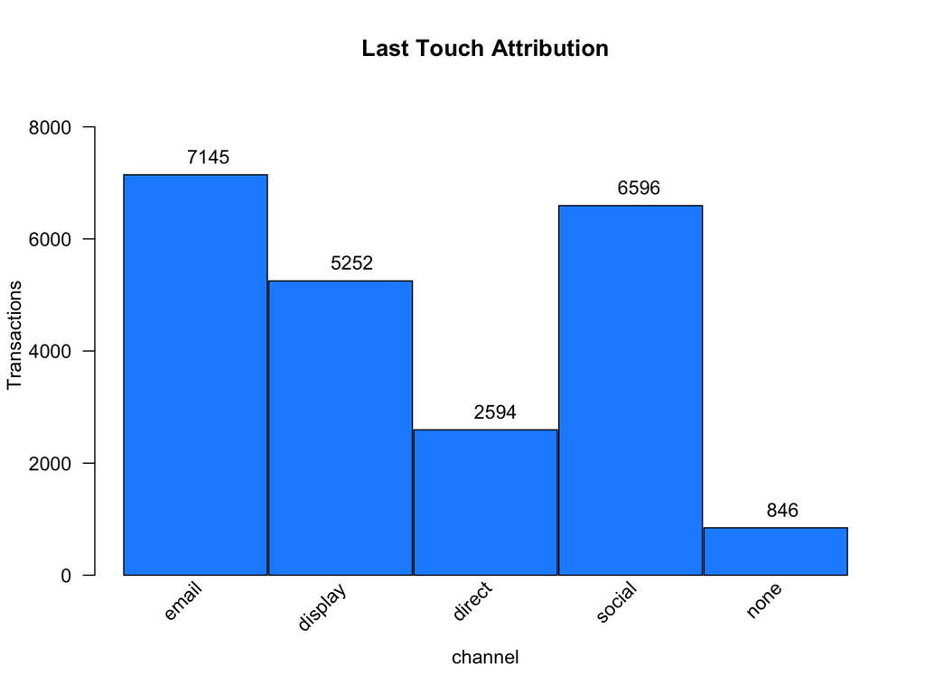

- **Implementation B**: Shiny reporting engine: last touch analysis result for subgroups of transactions.
- **Results & Interpretation**: majority of conversions happen after receiving the ads through email, social media, and diplay.

## Method 2: Holdout Test

- **Analysis**: Conduct an experiment called holdout testing by randomly selecting the customers for the control group to be not exposed to an ad. Here, we picked 2017-01-31 to analyze the result of the holdout test for the first 10 days.
- **Implementation A**:

```
               consumed
group           FALSE TRUE
  control group   702  470
  test group     2613 2216
```

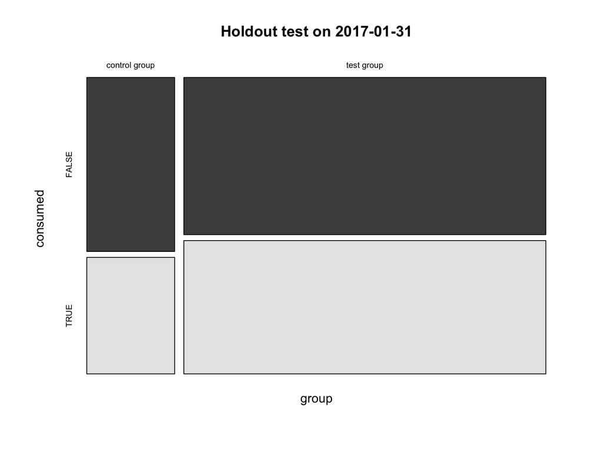

- **Results & Interpretation**: Seen from the table as well as the plot, it is obvious that the proportion of people made actual consumption in test group who have received the email ads is **higher** than that in control group who didn’t receive any email ads.

## Method 2: Holdout Test

```
    2-sample test for equality of proportions with continuity
    correction

data:  ttable[, "TRUE"] out of xtabs(~group, data = total.tab)
X-squared = 12.541, df = 1, p-value = 0.0003981
alternative hypothesis: two.sided
95 percent confidence interval:
 -0.08978269 -0.02595789
sample estimates:
   prop 1    prop 2
0.4010239 0.4588942
```

```
diff.prop 2         ci1         ci2
 0.05787029  0.08978269  0.02595789
```

- **Results & Interpretation**: the test group had a **45.89%** conversion rate in the first 10 days after the email was sent, while the hold out group had a **40.1%** conversion rate. The incremental increase in conversion rate is between **+2.60%** and **+8.98%** (95% confidence interval).
- **Implementation B**: Shiny reporting engine: the ad response over time for different email holdout test and for different duration

## Method 3: Marketing Mix Model (MMM)

- **Analysis**: In order to investigate the correlations between total sales (trainsactions) and impression factors within a specific time period, we implemented linear regression model for marketing mix modeling.

Model 1: Basic regression

Model 2: Add in a day of week variable

Model 3: Taking the advertising effect into consideration

Model 4: Interactions between Email and Social factors

- **Implementation：Let’s take a look at Model 3**

Account for the decay of advertising: An ad had its biggest **advertising effect** just after it is shown to the users and then the effect wears over the time.

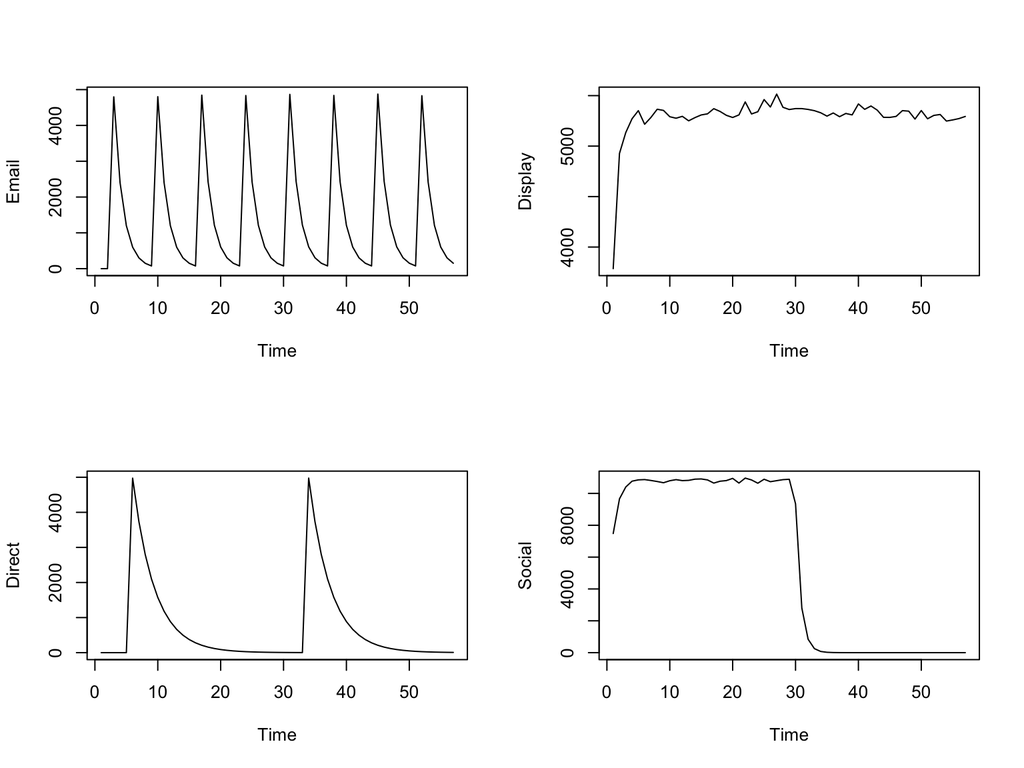

## Method 3: Marketing Mix Model (MMM)

```r
model.3<-fit.model(dt=mdata[10:nrow(mdata),c(1,8:11)], "Sales",
                   input.names=c("Email ad effect","Display ad effect","Direct ad effect","Social ad effect"),
                   model.type="linear", digits = 3)
datatable(model.3)
```

|  | Variable | Estimate | Std. Error | t value | Pr(>\|t\|) | Coef.Lower.95 | Coef.Upper.95 |
| --- | --- | --- | --- | --- | --- | --- | --- |
| 1 | (Intercept) | 199.476 | 704.798 | 0.283 | 0.779 | -1181.902 | 1580.854 |
| 2 | `Email ad effect` | 0.052 | 0.004 | 11.931 | 0 | 0.044 | 0.061 |
| 3 | `Display ad effect` | 0.004 | 0.132 | 0.028 | 0.978 | -0.256 | 0.263 |
| 4 | `Direct ad effect` | 0.056 | 0.007 | 7.777 | 0 | 0.042 | 0.071 |
| 5 | `Social ad effect` | 0.009 | 0.001 | 6.658 | 0 | 0.007 | 0.012 |

- **Results & Interpretation:**

Positive effects for all forms of advertising.

**Email** and **Direct** appears to have similar influence on sales at about 50 additional sales.

All effects are statistically significant except for **Display**. **Display** still has a high standard error because there is not a big change after the adjustment.

## Method 4: Model-based Attribution Analysis

- **Analysis:** Different from the MMM method, model-based attribution focuses on the **user level** by relating user transactions to prior advertising impressions. By visualizing this relationship as below, it is easy to see that users convert more on days they get emails or direct mails.

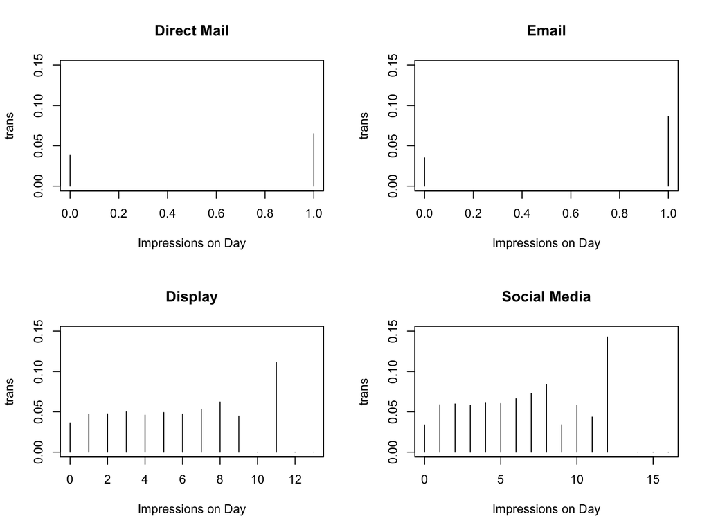

## Method 4: Model-based Attribution Analysis

- **Implementation:**

```r
model.4<-fit.model(dt = adata, "trans", input.names=c("direct", "display","email", "social", "past.purchase"),
                   model.type="logistic", digits = 3)
datatable(model.4)
```

|  | rn | Estimate | Std. Error | z value | Pr(>\|z\|) | Odds.Ratio | OR.Lower.95 | OR.Upper.95 |
| --- | --- | --- | --- | --- | --- | --- | --- | --- |
| 1 | (Intercept) | -4.023 | 0.014 | -287.078 | 0 | 0.018 | 0.017 | 0.018 |
| 2 | direct | 0.413 | 0.042 | 9.896 | 0 | 1.511 | 1.392 | 1.639 |
| 3 | display | 0.101 | 0.007 | 15.291 | 0 | 1.106 | 1.092 | 1.12 |
| 4 | email | 0.762 | 0.02 | 38.099 | 0 | 2.143 | 2.061 | 2.229 |
| 5 | social | 0.18 | 0.005 | 33.621 | 0 | 1.197 | 1.185 | 1.21 |
| 6 | past.purchase1 | 0.957 | 0.016 | 61.079 | 0 | 2.604 | 2.526 | 2.686 |

- **Results & Interpretation:**

From the summary, we could tell that **email** has the highest positive impact on the transaction - each email could increase 114% of probability for the transaction. The second highest channel is **direct mail** - each direct mail could increase 51% of probability for the transaction. Another notable fact is that the customers who have purchased before will significantly and positively impact the transactions - they are 160% more likely to purchase.

## Limitations and Uncertainties

- **Simulated dataset**: data is simulated but not real
- **Other marketing channels**: marketing channels in this case are limited
- **Holdout test on Tuesday only**: On 2017-01-03, 2017-01-17, 2017-01-24, 2017-01-31, 2017-02-07, 2017-02-14, and 2017-02-21, we conducted holdout test. But we cannot see if the result would be different on other days during a week.
- **Small dataset**: After combing the data, the informative dataset is not large enough to reach solid conclusions. Additionally, as the daily display impressions in the simulated dataset are pretty much the same, the data is not that informative from this perspective.